# Final

```
## # A tibble: 116,200 x 11
##    Canceled Type      Lead Month Guests  Days  Rate Deposit   Cars Cancellations
##       <dbl> <chr>    <dbl> <chr>  <int> <int> <dbl> <chr>    <dbl>         <dbl>
##  1        0 Resort ~     7 July       1     1   75  No Depo~     0             0
##  2        0 Resort ~    13 July       1     1   75  No Depo~     0             0
##  3        0 Resort ~    14 July       2     2   98  No Depo~     0             0
##  4        0 Resort ~    14 July       2     2   98  No Depo~     0             0
##  5        0 Resort ~     0 July       2     2  107  No Depo~     0             0
##  6        0 Resort ~     9 July       2     2  103  No Depo~     0             0
##  7        1 Resort ~    85 July       2     3   82  No Depo~     0             0
##  8        1 Resort ~    75 July       2     3  106. No Depo~     0             0
##  9        1 Resort ~    23 July       2     4  123  No Depo~     0             0
## 10        0 Resort ~    35 July       2     4  145  No Depo~     0             0
## # ... with 116,190 more rows, and 1 more variable: Changes <dbl>
```

Variables to focus on: If they’ve canceled this booking, how far in advanced they booked, month of booking, how many days stayed, how many guests, rate, if a deposit was made, if they’re bringing cars, if they’ve canceled before. Guests and days are combined for ease, but if they show any kind of correlation it may be worth un-joining them

```
## # A tibble: 116,200 x 11
##    Canceled  Type  Lead Month Guests  Days  Rate Deposit  Cars Cancellations
##       <dbl> <int> <dbl> <int>  <int> <int> <dbl>   <int> <dbl>         <dbl>
##  1        0     0     7    11      1     1   75        0     0             0
##  2        0     0    13    11      1     1   75        0     0             0
##  3        0     0    14    11      2     2   98        0     0             0
##  4        0     0    14    11      2     2   98        0     0             0
##  5        0     0     0    11      2     2  107        0     0             0
##  6        0     0     9    11      2     2  103        0     0             0
##  7        1     0    85    11      2     3   82        0     0             0
##  8        1     0    75    11      2     3  106.       0     0             0
##  9        1     0    23    11      2     4  123        0     0             0
## 10        0     0    35    11      2     4  145        0     0             0
## # ... with 116,190 more rows, and 1 more variable: Changes <dbl>
```

[figure not shown]

Relevant correlation with deposit, lead time, cars, type, previous cancellations, changes requested so filtering data further

```
## # A tibble: 11,697 x 7
##    Canceled  Lead  Type  Cars Cancellations Changes Deposit
##       <dbl> <dbl> <int> <dbl>         <dbl>   <dbl>   <int>
##  1        0    72     0     0             0       1       0
##  2        0    77     0     0             0       0       0
##  3        0     1     0     1             0       0       0
##  4        0     0     0     0             0       0       0
##  5        0     0     0     0             0       0       0
##  6        1   101     0     0             0       0       0
##  7        0     3     0     1             0       0       0
##  8        0    72     0     1             0       0       0
##  9        0     9     0     1             0       0       0
## 10        0   109     0     0             0       0       0
## # ... with 11,687 more rows
```

Establishing a train set and test set

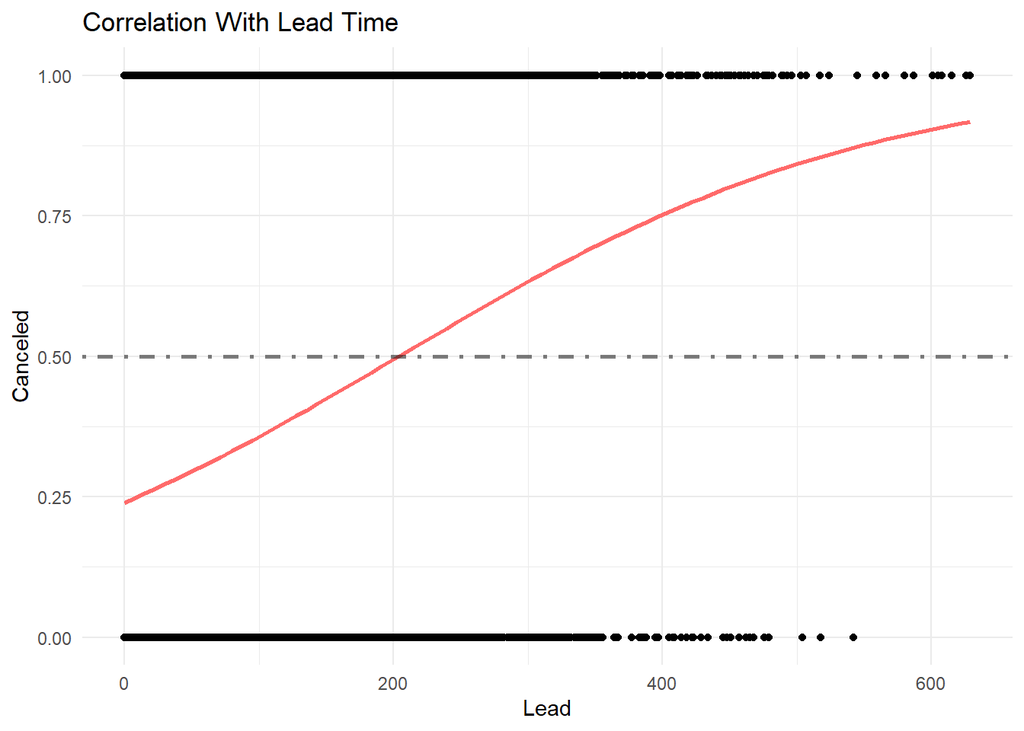

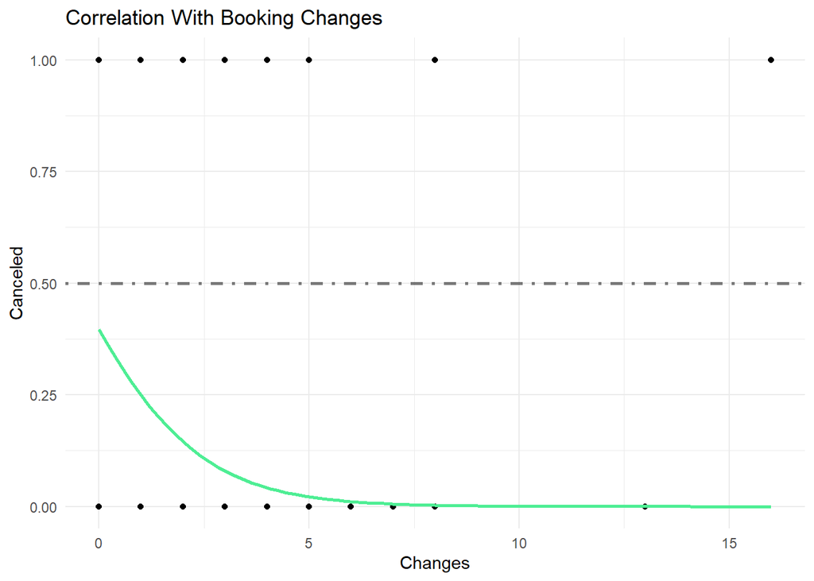

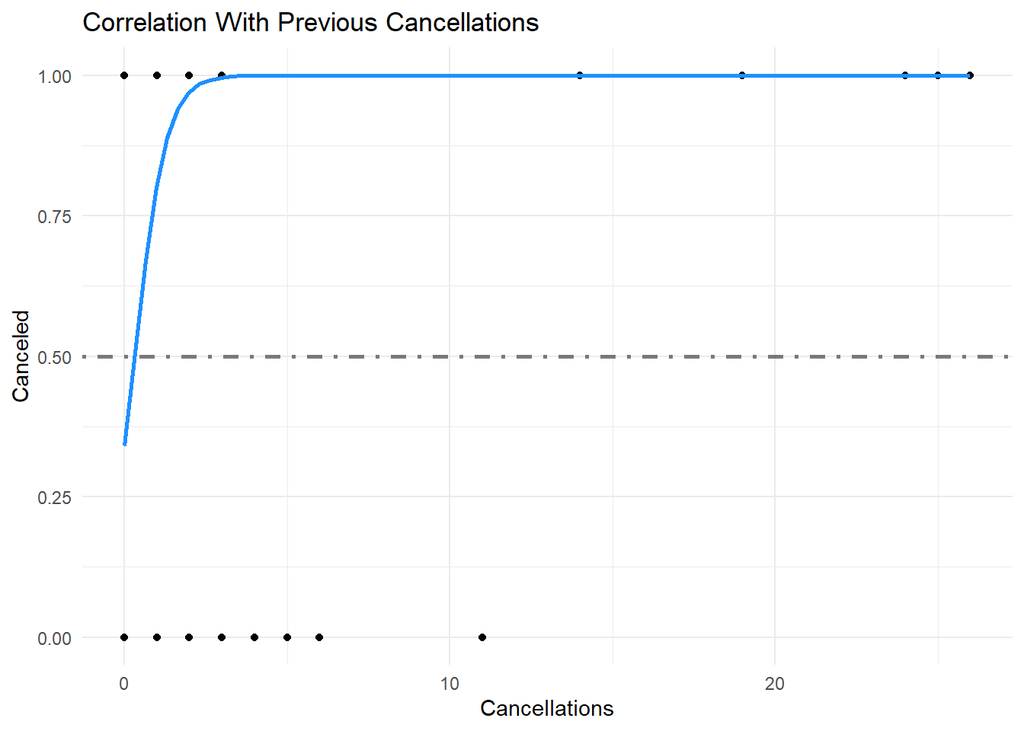

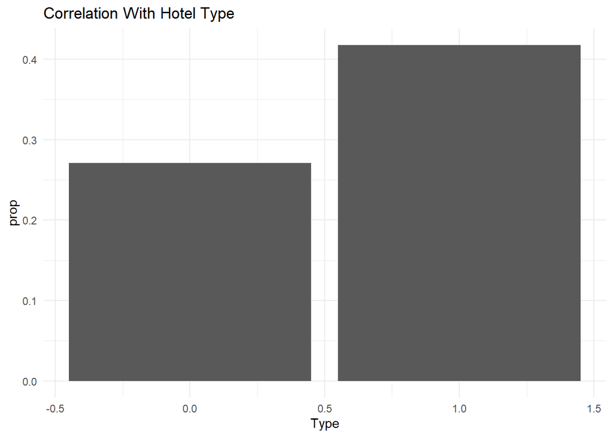

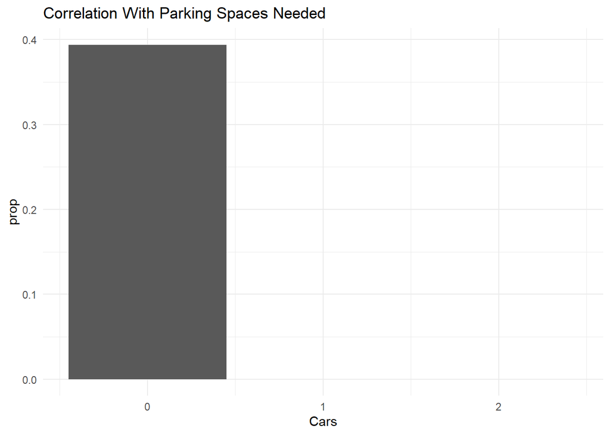

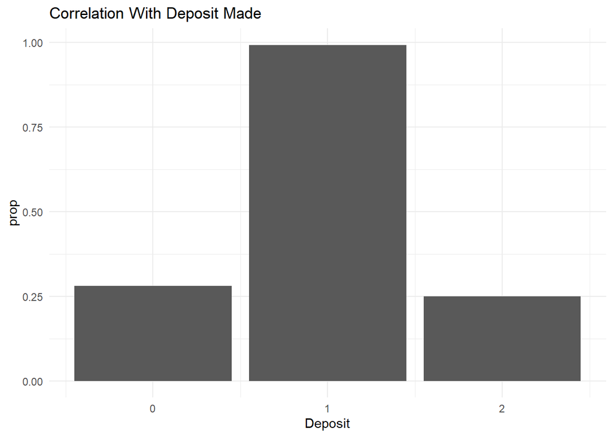

Plotting relationships for each variable:

-Longer lead time = more likely to cancel

-More booking changes = less likely

-Previously canceled = extremely likely

-More likely to cancel at the city

-No cancellations for people who reserve parking spaces

-Big issue with the non-refundable deposit?

Non Refundable

| Canceled | Count |
| --- | --- |
| 0 | 92 |
| 1 | 14462 |

Checking the entire dataset, this is hugely off-balance.

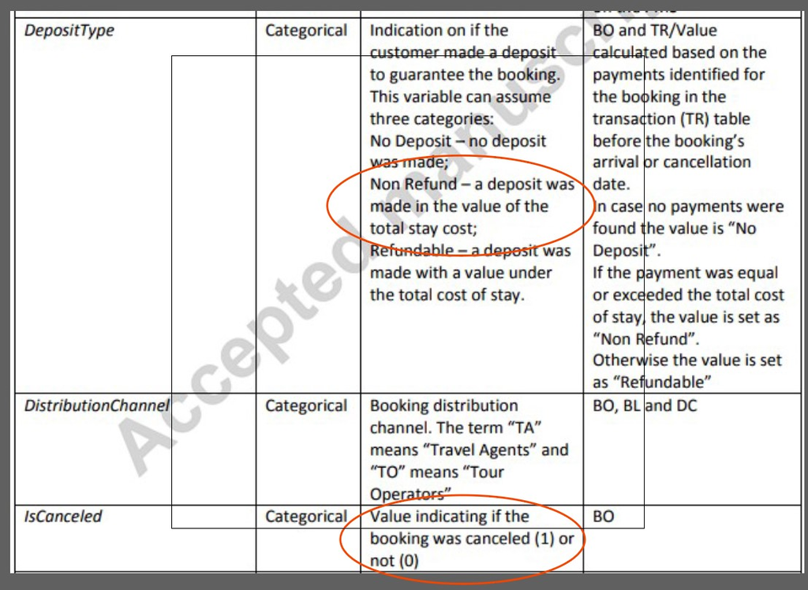

Nothing in the report for the data indicates why this is the case.

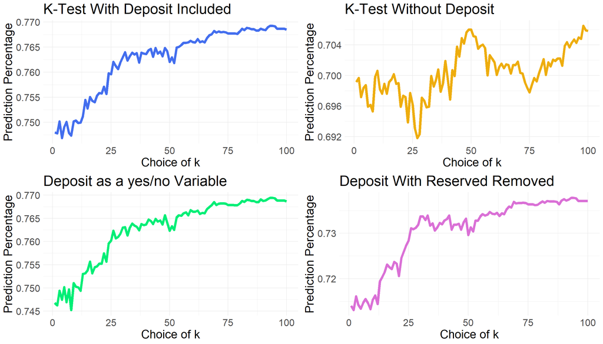

Optimal Values by Constraint

| Data Option | Optimal K | Percentage |
| --- | --- | --- |
| All Deposit | 93 | 76.93% |
| No Deposit | 98 | 70.65% |
| Combined | 93 | 76.94% |
| Removed | 93 | 73.78% |

```r
LAYOUT=matrix(c(1,3,2,4),ncol=2)
grid.arrange(M1,M2,M3,M4,layout_matrix=LAYOUT)
```

After running the test for 4 different variations of the data, I’m still tempted to remove the data (option 4) even though it’s over 10,000 observations. That still leaves us with 100,000 observations, and I really do feel like there’s something wrong with how those deposits are recorded…